# Safety from Trauma

Author

Vincent Pancini

Published

May 7, 2026

```r
options(scipen = 999)

library(urbnthemes)
library(tidyverse)
library(tidylog)
library(testthat)

source(here::here("functions", "testing", "evaluate_final_data.R"))

set_urbn_defaults(style = "print")
```

This metric is a county-level estimate of exposure to trauma, defined as the number of deaths due to injury per 100,000 population.

The rest of this file is organized as follows:

1. Background
2. Manually download mortality data from CDC WONDER
3. Read in and clean mortality data
4. Join mortality data onto universe of Urban counties
5. Validation
6. Add data quality flags
7. Save the data

All data used in this file are available on Box [here](https://urbanorg.box.com/s/lqoem3k7kc6nlhcqukudmo8nzw1cz3gn). Data stored on Box are only available to Urban Institute researchers.

# 0. Background and Changes

## 0.1 Changes from previous round of metric updates

- Adds newest year of data (2024).
- The data used in the creation of this metric come from CDC WONDER’s Underlying Cause of Death data. Past rounds of updates (data years 2014-2020) used the Bridged-Race Categories version of the data (available for years 1999-2020). Those data were discontinued, and after 2020, only the Single-Race Categories version of the data are available (for years 2018-2024). Past years reported age-adjusted mortality rates, but the Single-race Categories only allow for crude mortality rates. So, we updated past years to report crude rates instead of age-adjusted rates.
- We’ve added four subgroups for race/ethnicity for data years 2021 and beyond: Non-Hispanic White, Non-Hispanic Black, Hispanic, and Non-Hispanic Other.
- CDC WONDER changed how it reports counties with zero deaths starting with the 2024 data. In prior years, counties with zero deaths had their crude rate marked as “Unreliable,” which the code converted to NA. In the 2024 data, these counties instead have a literal crude rate of 0.0. We now explicitly set the rate (and confidence interval bounds) to NA when a county has zero deaths, consistent with how prior years were handled. This affects 3 counties in the “all” file (Kalawao County, HI; Clark County, ID; Kenedy County, TX) and many more in the subgroup files where small counties frequently have zero deaths for specific race/ethnicity groups.
- Last update, we compared our results to those produced by County Health Rankings and Roadmaps. We cannot do that this year because they use the restricted-use mortality data instead of the publicly available data from CDC WONDER.

## 0.2 Background

This section provides background for the data and considerations used to create this metric.

The data for this metric are national mortality and population data produced by the National Center for Health Statistics (NCHS) at the Centers for Disease Control and Prevention (CDC). Mortality information is collected by state registries and provided to the National Vital Statistics System. Data are based on death certificates for U.S. residents, and each death certificate contains a single underlying cause of death. Causes of death for 1999 and beyond are classified in accordance with the International Classification of Disease Tenth Revision (ICD-10). We use the following ICD-10 codes to identify injury deaths (note that County Health Rankings uses the same list of ICD-10 codes for their numerator of this metric ([source](https://www.countyhealthrankings.org/health-data/health-factors/social-economic-factors/community-safety/injury-deaths?year=2024))):

- *U01 (Terrorism - Assault (homicide) )
- *U02 (Sequelae of terrorism)
- *U03 (Terrorism Intentional (Suicide))
- V01-V99 (Transport accidents)
- W00-X59 (Other external causes of accidental injury)
- X60-X84 (Intentional self-harm)
- X85-Y09 (Assault)
- Y10-Y34 (Event of undetermined intent)
- Y35-Y36 (Legal intervention and operations of war)
- Y85 (Sequelae of transport accidents)
- Y86 (Sequelae of other accidents)
- Y87 (Sequelae of intentional self-harm, assault and events of undetermined intent)
- Y89 (Sequelae of other external causes)

The mortality micro-data files are restricted and require research-proposal review and approval by the [National Center for Health Statistics](https://www.cdc.gov/nchs/nvss/nvss-restricted-data.htm). Therefore we use the mortality data made publicly available through [CDC WONDER](https://wonder.cdc.gov/deaths-by-underlying-cause.html, an online system that makes CDC data available to the public.

To protect personal privacy and meet confidentiality constraints, CDC WONDER applies the following suppression rules to the raw NCHS mortality data before making them publicly available:

- Rates are suppressed for data representing zero to nine (0-9) deaths. Corresponding denominator population figures are also suppressed when the population represents fewer than 10 persons.
- Rates are marked as “unreliable” when the death count is less than 20.
- Rates are marked as “not applicable” when the population denominator figure is unavailable, such as persons of “not stated” or unknown age or Hispanic origin.

There are two options for these mortality data on CDC WONDER: 1. 2018-2024: Underlying Cause of Death by Single-Race Categories 2. 1999-2020: Underlying Cause of Death by Bridged-Race Categories

### 0.2a Bridged-Race vs Single-Race

For 1979-2002, all 50 States and the District of Columbia collected race data on the death certificates using four single-race categories (American Indian or Alaska Native, Asian or Pacific Islander, Black, and White) in accordance with the 1977 OMB standards, allowing only a single race to be reported. Beginning with the 2003 data year, some States began collecting race data in accordance with the 1997 OMB standards, allowing one or more of five race categories to be reported. In order to provide uniformity and comparability of mortality data during the transition from the single-race format to the multiple-race format, NCHS is “bridging” the race responses of those for whom more than one race is reported (multiple race) to one of the single-race categories. The bridging procedure is similar to the procedure used to bridge multiple-race population estimates. Multiple-race decedents are imputed to a single race (White, Black, American Indian or Alaska Native, or Asian or Pacific Islander) according to their combination of races, Hispanic origin, sex, and age indicated on the death certificate ([source](https://wonder.cdc.gov/wonder/help/mcd.html)).

The 2011-2020 population estimates are postcensal estimates of the July 1 resident population. The release of postcensal bridged-race population estimates ceased with the release of the Vintage 2020 estimates. Therefore, mortality rates are only available through CDC WONDER by Single-Race Categories for years 2021 and beyond. We include subgroups by race/ethnicity for 2021 and beyond, but do not include subgroups for 2020 and prior years because the race categories are not comparable to those for 2021 and beyond.

### 0.2b Crude Rates vs Age-Adjusted Rates

Age-adjusted death rates are weighted averages of the age-specific death rates, where the weights represent a fixed population by age. They are used to compare relative mortality risk among groups and over time. An age-adjusted rate represents the rate that would have existed had the age-specific rates of the particular year prevailed in a population whose age distribution was the same as that of the fixed population. Age adjustment “removes” the effects of age from crude rates which allows for meaningful comparisons across populations with different age distributions. Age-adjusted rates should be viewed as relative indexes rather than as direct or actual measures of mortality risk.

Crude rates are helpful in determining the need for services for a given population, relative to another population, regardless of size. Crude rates are influenced by the underlying age distribution of the state’s population. Even if two states have the same age-adjusted rates, the state with the relatively older population (as demonstrated by having a higher median age) will have higher crude rates because incidence or death rates for most cancers increase with increasing age.

Age-adjusted rates are not available at the county level for analysis of mortality by Single-Race categories because the populations are weighted to the 10-year age groups, and county level populations estimates are not available for the “<1 year” and “1-4 years” age categories. Even if we exclude these age categories, CDC WONDER will not produce age-adjusted rates with the Single-Race data.

In past rounds of metric updates, with data years 2020 and prior, we reported age-adjusted mortality rates. Because age-adjusted rates are no longer available for data years 2021 and beyond, we have changed data years 2020 and prior to report crude rates as well instead of age-adjusted rates.

## 0.3 Considerations for future metric updates

- Other subgroups available for construction through CDC WONDER include age groups (ten-year age groups, five-year age groups, and single-year age groups), sex, and education. The next round of updates may want to consider including additional subgroups, and will have to consider CDC WONDER’s data suppression criteria for any subgroup.
- Rather than selecting injury deaths from the list of ICD-10 codes, CDC WONDER includes a section that allows users to specify deaths by “Injury Intent and Mechanism.” Future updates may want to consider relying on this functionality, or at least comparing it to the ICD-10 codes that we’ve specified.
- The quality values are based on the coefficient of variation (CV) for each estimate, but the range of CVs is relatively narrow. Future updates may want to consider assigning quality based on different CV values.

# 1. Manually download mortality data from CDC WONDER

This section explains the manual download process to create data extracts for these data from CDC WONDER. All data used in this file are available on Box [here](https://urbanorg.box.com/s/lqoem3k7kc6nlhcqukudmo8nzw1cz3gn). Data stored on Box are only available to Urban Institute researchers.

There is an API available for CDC WONDER data. However, only national data are available for query by the API. Queries for mortality statistics from the National Vital Statistics System cannot limit or group results by any location field such as county. Therefore, we must manually download the data.

For each year of data accessed, we pool the most recent five years (consistent with County Health Rankings). E.g., for 2020, we pool data from 2016, 2017, 2018, 2019, and 2020. For each year, the user will need to repeat the steps with the correct five-year pool (e.g., for 2019 data, the user should select 2015, 2016, 2017, 2018, and 2019). This is explained in more detail in the next section.

### 2.1 Manually download Underlying Cause of Death by Bridged-Race Categories (2014-2020)

#### 2.1a Navigate to extract page

1. Navigate to the Mortality Data homepage on CDC WONDER [here](https://wonder.cdc.gov/Deaths-by-Underlying-Cause.html).
2. Select [1999-2020: Underlying Cause of Death by Bridged-Race Categories](https://wonder.cdc.gov/ucd-icd10.html)
3. Select “I Agree” at the bottom of the page.

#### 2.1b Create extracts for each year 2014-2020

Create your extract for each year according to the specifications below. Note that the specific extract created by these specifications only creates the data file for 2020. You will need to modify and re-submit the query 6 times to get data files for 2014-2019. Instructions for how to do so are explained after the 2020 extract specifications.

1. Organize table layout:
- Group Results By: County
- Measures: Deaths, Population, Crude Rate, 95% Confidence Interval (Crude Rate), Standard Error (Crude Rate), Age Adjusted Rate, 95% Confidence Interval (Age Adjusted Rate), Standard Error (Age Adjusted Rate)
- Title: `injury_deaths_all_YYYY` where `YYYY` represents the most recent year in the five-year pool (e.g., if the pool includes years 2016, 2017, 2018, 2019, and 2020, name the file `injury_deaths_all_2020`)
2. Select location:
- States
- States: *All* (The United States)
- 2013 Urbanization: All Categories
3. Select demographics:
- Ten-Year Age Groups: All Ages
- Sex: All
- Hispanic Origin: All Origins
- Race: All Races
4. Select year and month:
- Year/Month: 2016, 2017, 2018, 2019, 2020 (select all at once)
5. Select weekday, autopsy and place of death:
- Weekday: All Weekdays
- Autopsy: All Values
- Place of Death: All Places
6. Select cause of death:
- ICD-10 Codes
- ICD-10 Codes:
  - *U01 (Terrorism - Assault (homicide) )
  - *U02 (Sequelae of terrorism)
  - *U03 (Terrorism Intentional (Suicide))
  - V01-V99 (Transport accidents)
  - W00-X59 (Other external causes of accidental injury)
  - X60-X84 (Intentional self-harm)
  - X85-Y09 (Assault)
  - Y10-Y34 (Event of undetermined intent)
  - Y35-Y36 (Legal intervention and operations of war)
  - Y85 (Sequelae of transport accidents)
  - Y86 (Sequelae of other accidents)
  - Y87 (Sequelae of intentional self-harm, assault and events of undetermined intent)
  - Y89 (Sequelae of other external causes)
7. Other options:
- Show Totals
- Show Zero Values
- Show Suppressed Values
- Precision: 1 decimal places
- Data Access Timeout: 10 minutes

After creating the extract to the above specifications: - Select `Send` at the bottom of the page to submit the extract.

- Select `Export` at the top right of the `Results` page. This will automatically download a `.txt` file titled `injury_deaths_all_YYYY.txt` to your Downloads folder
- Move the `.txt` file from your Downloads folder to the `mobility-from-poverty\20_safety-from-trauma\data\bridged-race` directory.

Note that to recreate this metric for all years, the user will need to submit the extract 7 total times. The only thing that changes with each submit is the combination of years chosen. Each data year includes the current year and the previous four years to create a five-year pool. After exporting your resulting `.txt` file for the first extract, navigate back to the `Request Form` by clicking the `Request Form` tab on the top left of the screen. The only thing you need to change is the combination of years under `Year/Month` in the `4. Select year and month:` section. Select:

- 2016, 2017, 2018, 2019, and 2020 and then click `Send` at the bottom of the screen to create the 2020 data file
- 2015, 2016, 2017, 2018, and 2019 and then click `Send` at the bottom of the screen to create the 2019 data file
- 2014, 2015, 2016, 2017, and 2018 and then click `Send` at the bottom of the screen to create the 2018 data file
- 2013, 2014, 2015, 2016, and 2017 and then click `Send` at the bottom of the screen to create the 2017 data file
- 2012, 2013, 2014, 2015, and 2016 and then click `Send` at the bottom of the screen to create the 2016 data file
- 2011, 2012, 2013, 2014, and 2015 and then click `Send` at the bottom of the screen to create the 2015 data file
- 2010, 2011, 2012, 2013, and 2014 and then click `Send` at the bottom of the screen to create the 2014 data file

### 2.2 Manually download Underlying Cause of Death by Single-Race Categories (2021-2024)

#### 2.2a Navigate to extract page

1. Navigate to the Mortality Data homepage on CDC WONDER [here](https://wonder.cdc.gov/Deaths-by-Underlying-Cause.html).
2. Select [2018-2024: Underlying Cause of Death by Single-Race Categories](https://wonder.cdc.gov/ucd-icd10-expanded.html)
3. Select “I Agree” at the bottom of the page.

#### 2.2b Create extracts for each year 2021-2024

Create your extract for each year according to the specifications below. Note that the specific extract created by these specifications only creates the data file for 2024. You will need to modify and re-submit the query 3 times to get data files for 2021-2023. Instructions for how to do so are explained after the 2024 extract specifications.

1. Organize table layout:
- Group Results By: County
- Measures: Deaths, Population, Crude Rate, 95% Confidence Interval (Crude Rate), Standard Error (Crude Rate)
- Title: `injury_deaths_all_YYYY` where `YYYY` represents the most recent year in the five-year pool (e.g., if the pool includes years 2020, 2021, 2022, 2023, and 2024 name the file `injury_deaths_all_2024`)
2. Select location:
- States
- States: *All* (The United States)
- 2013 Urbanization: All Categories
3. Select demographics:
- Ten-Year Age Groups: All Ages
- Gender: All Genders
- Hispanic Origin: All Origins
- Single Race 6: All Races
4. Select year and month:
- Year/Month: 2020, 2021, 2022, 2023, 2024 (select all at once)
5. Select weekday, autopsy and place of death:
- Weekday: All Weekdays
- Autopsy: All Values
- Place of Death: All Places
6. Select cause of death:
- ICD-10 Codes
- ICD-10 Codes:
  - *U01 (Terrorism - Assault (homicide) )
  - *U02 (Sequelae of terrorism)
  - *U03 (Terrorism Intentional (Suicide))
  - V01-V99 (Transport accidents)
  - W00-X59 (Other external causes of accidental injury)
  - X60-X84 (Intentional self-harm)
  - X85-Y09 (Assault)
  - Y10-Y34 (Event of undetermined intent)
  - Y35-Y36 (Legal intervention and operations of war)
  - Y85 (Sequelae of transport accidents)
  - Y86 (Sequelae of other accidents)
  - Y87 (Sequelae of intentional self-harm, assault and events of undetermined intent)
  - Y89 (Sequelae of other external causes)
7. Other options:
- Show Totals
- Show Zero Values
- Show Suppressed Values
- Precision: 1 decimal places
- Data Access Timeout: 10 minutes

After creating the extract to the above specifications: - Select `Send` at the bottom of the page to submit the extract.

- Select `Export` at the top right of the `Results` page. This will automatically download a `.txt` file titled `injury_deaths_all_YYYY.txt` to your Downloads folder.
- Move the `.txt` file from your Downloads folder to the `mobility-from-poverty\20_safety-from-trauma\data\single-race\all` directory.

Note that to recreate this metric for all years, the user will need to submit the extract 4 total times. The only thing that changes with each submit is the combination of years chosen. Each data year includes the current year and the previous four years to create a five-year pool. After exporting your resulting `.txt` file for the first extract, navigate back to the `Request Form` by clicking the `Request Form` tab on the top left of the screen. The only thing you need to change is the combination of years under `Year/Month` in the `4. Select year and month:` section. Select:

- 2019, 2020, 2021, 2022, and 2023 and then click `Send` at the bottom of the screen to create the 2023 data file
- 2018, 2019, 2020, 2021, and 2022 and then click `Send` at the bottom of the screen to create the 2022 data file
- 2018, 2019, 2020, and 2021 and then click `Send` at the bottom of the screen to create the 2021 data file
  - Note that the Single-Race Categories data are only available starting in 2018, so for 2021 we can only get a four-year pool of data. This is the only year that does not include a five-year pool of data.

#### 2.2c Create extracts for each year 2021-2024 - race/ethnicity subgroups

Repeat the steps above to create race/ethnicity subgroups for each year. In section `3. Select demographics` of the CDC WONDER extract page, construct the following four race groups for each year:

- Non-Hispanic White: `Hispanic Origin` - Not Hispanic or Latino. `Single Race 6` - White (name the title of the extract `injury_deaths_raceth_nhwhite_YYYY`).
- Non-Hispanic Black: `Hispanic Origin` - Not Hispanic or Latino. `Single Race 6` - Black or African American (name the title of the extract `injury_deaths_raceth_nhblack_YYYY`).
- Hispanic: `Hispanic Origin` - Hispanic or Latino. `Single Race 6` - All Races (name the title of the extract `injury_deaths_raceth_hisp_YYYY`).
- Non-Hispanic Other: `Hispanic Origin` - Not Hispanic or Latino. `Single Race 6` - American Indian or Alaska Native; Asian; Native Hawaiian or Other Pacific Islander; More than one race (name the title of the extract `injury_deaths_raceth_nhother_YYYY`).

Move all of the resulting `.txt` files from your Downloads folder to the `mobility-from-poverty\20_safety-from-trauma\data\single-race\subgroups` directory.

# 2. Read in and clean mortality data

## 2.1 Bridged Race (2014-2020), All

List all the files in the `bridged-race` folder

```r
paths <- list.files(here::here("20_safety-from-trauma", "data", "bridged-race"),
                    pattern = "[.]txt$", full.names = TRUE)
```

Check that all files have been properly downloaded

```r
# Create list of expected years
expected_years <- tribble(
  ~year,
  "2014",
  "2015",
  "2016",
  "2017",
  "2018",
  "2019",
  "2020"
)

# Use years above to create vector of expected files
expected_files <- c(
  here::here(paste0("20_safety-from-trauma/data/bridged-race/injury_deaths_all_",
                    expected_years$year,
                    ".txt"))
)

# Ensure expected files are included in the `bridged-race` directory before proceeding
if(!all(expected_files %in% paths)) {
  stop("Error: Some expected files are missing. Please refer to the download directions in section 2 above.")
}
```

```r
deaths_br_raw <- paths |>
  set_names(basename(paths)) |>  # Name elements of paths by their filenames
  map_dfr(
    ~ utils::read.delim(.x) |>
      mutate(
        Deaths = as.character(Deaths),  # Convert Deaths to character for consistency
        Population = as.numeric(Population)
      ),
    .id = "filename"  # Add the filename as a column
  ) |>
  mutate(
    year = parse_number(filename),  # Extract year from filename
    subgroup_type = str_extract(filename, "(all)"), # Extract subgroup from filename
  )
```

```r
if (any(as.numeric(deaths_br_raw$Deaths) %in% 1:9)) {

  stop("Do not use death counts in 1:9")

}
```

The raw `.txt` files which we read in from CDC WONDER contains a `Notes` column which we drop. We retain all information for the crude death rate (rate, confidence interval, and standard error).

```r
# Rename variables, remove `Notes` column
deaths_br_clean <- deaths_br_raw |>
  select(
    year,
    county_name = County,
    GEOID = County.Code,
    rate_injury_death = Crude.Rate,
    rate_injury_death_lb = Crude.Rate.Lower.95..Confidence.Interval,
    rate_injury_death_ub = Crude.Rate.Upper.95..Confidence.Interval,
    rate_injury_death_se = Crude.Rate.Standard.Error,
    deaths = Deaths,
    subgroup_type
  ) |>
  # Remove empty rows resulting from deleting the `Notes` column, and remove the total row
  filter(!is.na(GEOID)) |>
  # Replace "suppressed", "unreliable", and "missing" values with NA
  mutate(
    across(
      .cols = c(starts_with("rate"), deaths
      ),
      ~ifelse(. %in% c("Suppressed", "Unreliable", "Missing"), NA, .))) |>
  # Change values from character to numeric
  mutate(across(.cols = c(starts_with("rate"), deaths), .fns = as.numeric)) |>
  # Edit GEOID
  mutate(GEOID = str_pad(GEOID, 5, pad = "0")) |>
  mutate(subgroup = "all")
```

## 2.2 Single Race (2021-2024), All

```r
paths <- list.files(here::here("20_safety-from-trauma", "data", "single-race", "all"),
                    pattern = "[.]txt$", full.names = TRUE)
```

Check that all files have been properly downloaded

```r
# Create list of expected years
expected_years <- tribble(
  ~year,
  "2021",
  "2022",
  "2023",
  "2024",
)

# Use years above to create vector of expected files
expected_files <- c(
  here::here(paste0("20_safety-from-trauma/data/single-race/all/injury_deaths_all_",
                    expected_years$year,
                    ".txt"))
)

# Ensure expected files are included in the `single-race\all` directory before proceeding
if(!all(expected_files %in% paths)) {
  stop("Error: Some expected files are missing. Please refer to the download directions in section 2 above.")
}
```

```r
deaths_sr_raw <- paths |>
  set_names(basename(paths)) |>  # Name elements of paths by their filenames
  map_dfr(
    ~ utils::read.delim(.x) |>
      mutate(
        Deaths = as.character(Deaths),  # Convert Deaths to character for consistency
        Population = as.numeric(Population)
      ),
    .id = "filename"  # Add the filename as a column
  ) |>
  mutate(
    year = parse_number(filename),  # Extract year from filename
    subgroup_type = str_extract(filename, "(all)"), # Extract subgroup from filename
  )
```

```r
if (any(as.numeric(deaths_sr_raw$Deaths) %in% 1:9)) {

  stop("Do not use death counts in 1:9")

}
```

The raw `.txt` files which we read in from CDC WONDER contains a `Notes` column which we drop. We retain all information for the crude death rate (rate, confidence interval, and standard error).

```r
# Rename variables, remove `Notes` column
deaths_sr_clean <- deaths_sr_raw |>
  select(
    year,
    county_name = County,
    GEOID = County.Code,
    rate_injury_death = Crude.Rate,
    rate_injury_death_lb = Crude.Rate.Lower.95..Confidence.Interval,
    rate_injury_death_ub = Crude.Rate.Upper.95..Confidence.Interval,
    rate_injury_death_se = Crude.Rate.Standard.Error,
    deaths = Deaths,
    subgroup_type
  ) |>
  # Remove empty rows resulting from deleting the `Notes` column, and remove the total row
  filter(!is.na(GEOID)) |>
  # Replace "suppressed", "unreliable", and "missing" values with NA
  mutate(
    across(
      .cols = c(starts_with("rate"), deaths
      ),
      ~ifelse(. %in% c("Suppressed", "Unreliable", "Missing"), NA, .))) |>
  # Change values from character to numeric
  mutate(across(.cols = c(starts_with("rate"), deaths), .fns = as.numeric)) |>
  # Set rate to NA when deaths == 0 (CDC WONDER 2024+ reports 0.0 instead of "Unreliable")
  mutate(across(.cols = starts_with("rate"), ~if_else(deaths == 0, NA, .))) |>
  # Edit GEOID
  mutate(GEOID = str_pad(GEOID, 5, pad = "0")) |>
  mutate(subgroup = "all")
```

## 2.3 Single Race (2021-2024), Subgroups

```r
paths <- list.files(here::here("20_safety-from-trauma", "data", "single-race", "subgroups"),
                    pattern = "[.]txt$", full.names = TRUE)
```

Check that all files have been properly downloaded

```r
# Create list of expected years
expected_years <- tribble(
  ~year,
  "nhwhite_2021",
  "nhwhite_2022",
  "nhwhite_2023",
  "nhwhite_2024",
  "nhblack_2021",
  "nhblack_2022",
  "nhblack_2023",
  "nhblack_2024",
  "hisp_2021",
  "hisp_2022",
  "hisp_2023",
  "hisp_2024",
  "nhother_2021",
  "nhother_2022",
  "nhother_2023",
  "nhother_2024",
)

# Use years above to create vector of expected files
expected_files <- c(
  here::here(paste0("20_safety-from-trauma/data/single-race/subgroups/injury_deaths_raceth_",
                    expected_years$year,
                    ".txt"))
)

# Ensure expected files are included in the `single-race\subgroups` directory before proceeding
if(!all(expected_files %in% paths)) {
  stop("Error: Some expected files are missing. Please refer to the download directions in section 2 above.")
}
```

```r
deaths_sr_subgroups_raw <- paths |>
  set_names(basename(paths)) |>  # Name elements of paths by their filenames
  map_dfr(
    ~ utils::read.delim(.x) |>
      mutate(
        Deaths = as.character(Deaths),  # Convert Deaths to character for consistency
        Population = as.numeric(Population)
      ),
    .id = "filename"  # Add the filename as a column
  ) |>
  mutate(
    year = parse_number(filename),  # Extract year from filename
    subgroup_type = str_extract(filename, "(raceth)"), # Extract subgroup from filename
    subgroup = case_when(
      str_detect(filename, "nhwhite") ~ "nhwhite",
      str_detect(filename, "nhblack") ~ "nhblack",
      str_detect(filename, "hisp") ~ "hisp",
      str_detect(filename, "nhother") ~ "nhother",
      TRUE ~ NA_character_
    )
  )
```

```r
# Rename variables, remove `Notes` column
deaths_sr_subgroups_clean <- deaths_sr_subgroups_raw |>
  select(
    year,
    county_name = County,
    GEOID = County.Code,
    rate_injury_death = Crude.Rate,
    rate_injury_death_lb = Crude.Rate.Lower.95..Confidence.Interval,
    rate_injury_death_ub = Crude.Rate.Upper.95..Confidence.Interval,
    rate_injury_death_se = Crude.Rate.Standard.Error,
    deaths = Deaths,
    subgroup_type,
    subgroup
  ) |>
  # Remove empty rows resulting from deleting the `Notes` column, and remove the total row
  filter(!is.na(GEOID)) |>
  # Replace "suppressed", "unreliable", and "missing" values with NA
  mutate(
    across(
      .cols = c(starts_with("rate"), deaths
      ),
      ~ifelse(. %in% c("Suppressed", "Unreliable", "Missing"), NA, .))) |>
  # Change values from character to numeric
  mutate(across(.cols = c(starts_with("rate"), deaths), .fns = as.numeric)) |>
  # Set rate to NA when deaths == 0 (CDC WONDER 2024+ reports 0.0 instead of "Unreliable")
  mutate(across(.cols = starts_with("rate"), ~if_else(deaths == 0, NA, .))) |>
  # Edit GEOID
  mutate(GEOID = str_pad(GEOID, 5, pad = "0"))
```

## 2.4 Append death rates

```r
death_rates <- bind_rows(
  deaths_br_clean,
  deaths_sr_clean,
  deaths_sr_subgroups_clean
)
```

CDC WONDER reports rates as `unreliable` when the death count is less than 20, and as `suppressed` when the death count is less than 10. We changed these rates to `NA` in our data. We also want to change the lower bound, upper bound, and standard error to missing for these observations as well. Note that standard error isn’t included in the final file, but the confidence interval bounds are. There are also instances where the upper and lower bounds are 0 because there are 0 deaths, but the rate was `Unreliable`; these also get replaced as `NA` in the code below.

```r
death_rates <- death_rates |>
  mutate(
    rate_injury_death_lb = if_else(is.na(rate_injury_death), NA, rate_injury_death_lb),
    rate_injury_death_ub = if_else(is.na(rate_injury_death), NA, rate_injury_death_ub),
    rate_injury_death_se = if_else(is.na(rate_injury_death), NA, rate_injury_death_se)
  )
```

## 2.5 Reshape wide

```r
death_rates_wide <- death_rates |>
  select(-subgroup_type) |>
  pivot_wider(
    id_cols = c(year, county_name, GEOID),
    names_from = subgroup,
    names_sep = "_",
    values_from = c(rate_injury_death, rate_injury_death_lb, rate_injury_death_ub, rate_injury_death_se, deaths)
  )
```

```r
death_rates_wide |>
  group_by(year) |>
  count()
```

```
# A tibble: 11 × 2
# Groups:   year [11]
    year     n
   <dbl> <int>
 1  2014  3147
 2  2015  3147
 3  2016  3147
 4  2017  3147
 5  2018  3147
 6  2019  3147
 7  2020  3147
 8  2021  3142
 9  2022  3142
10  2023  3142
11  2024  3142
```

```r
# Clean up environment
rm(paths, expected_years, expected_files, deaths_br_raw, deaths_br_clean, deaths_sr_raw, deaths_sr_clean, deaths_sr_subgroups_raw, deaths_sr_subgroups_clean)
```

# 3. Join mortality data onto universe of Urban counties

This section reads in the Urban Institute’s universe of counties and joins the CDC injury death data to those counties.

## 3.1 Read in Urban county file for 2014-2020

```r
urban_counties <- readr::read_csv(here::here("geographic-crosswalks", "data", "county-populations.csv")) |>
  mutate(GEOID = str_c(state, county))

urban_counties |>
  group_by(year) |>
  count()
```

```
# A tibble: 11 × 2
# Groups:   year [11]
    year     n
   <dbl> <int>
 1  2014  3142
 2  2015  3142
 3  2016  3142
 4  2017  3142
 5  2018  3142
 6  2019  3142
 7  2020  3143
 8  2021  3143
 9  2022  3144
10  2023  3144
11  2024  3144
```

### 3.2 Identify counties in Urban universe but not in CDC WONDER

Some observations are in our universe of counties but not in the CDC data (from Alaska, Connecticut, and South Dakota).

- Chugach Census Area, AK is missing for 2020-2024.
- Copper River Census Area, AK is missing for 2020-2024.
- Kusilvak Census Area, AK is missing for 2015-2024.
- All 9 of Connecticut’s planning regions are missing for 2022-2024.
- Oglala Lakota County, SD is missing for 2015-2024

```r
missing_CDC <- anti_join(
  x = urban_counties,
  y = death_rates_wide,
  by = c("year", "GEOID")
  )

missing_CDC |>
  group_by(state_name, county_name) |>
  count(year)
```

```
# A tibble: 57 × 4
# Groups:   state_name, county_name [13]
   state_name county_name               year     n
   <chr>      <chr>                    <dbl> <int>
 1 Alaska     Chugach Census Area       2020     1
 2 Alaska     Chugach Census Area       2021     1
 3 Alaska     Chugach Census Area       2022     1
 4 Alaska     Chugach Census Area       2023     1
 5 Alaska     Chugach Census Area       2024     1
 6 Alaska     Copper River Census Area  2020     1
 7 Alaska     Copper River Census Area  2021     1
 8 Alaska     Copper River Census Area  2022     1
 9 Alaska     Copper River Census Area  2023     1
10 Alaska     Copper River Census Area  2024     1
# ℹ 47 more rows
```

Shannon County, SD was renamed to Oglala Lakota County, SD in 2014 (ratified early 2015) ([source](https://www.census.gov/programs-surveys/geography/technical-documentation/county-changes.2010.html#list-tab-957819518)). We convert Shannon County, SD to Oglala Lakota County, SD in the CDC deaths data to reflect this change.

```r
death_rates_wide <- death_rates_wide |>
  mutate(
    county_name = if_else(county_name == "Shannon County, SD" & year != "2014",
                          "Oglala Lakota County, SD",
                          county_name),
    GEOID = if_else(GEOID == "46113" & year != "2014",
                    "46102",
                    GEOID)
  )
```

Wade Hampton Census Area, AK was renamed to Kusilvak Census Area, AK in 2015 ([source](https://www.census.gov/programs-surveys/geography/technical-documentation/county-changes.2010.html#list-tab-957819518)). We convert Wade Hampton Census Area, AK to Kusilvak Census Area, AK in the CDC deaths data to reflect this change.

```r
death_rates_wide <- death_rates_wide |>
  mutate(
    county_name = if_else(county_name == "Wade Hampton Census Area, AK" & year != "2014",
                          "Kusilvak Census Area, AK",
                          county_name),
    GEOID = if_else(GEOID == "02270" & year != "2014",
                    "02158",
                    GEOID)
  )
```

### 3.3 Identify counties in CDC WONDER but not in Urban universe

After addressing the counties above, some observations are in the CDC data but not our universe of counties.

- Bedford city, VA is missing for 2014-2020
- Clifton Forge city, VA is missing for 2014-2020
- Prince of Wales-Outer Ketchikan Census Area, AK is missing for 2014-2020
- Skagway-Hoonah-Angoon Census Area, AK is missing for 2014-2020
- Wrangell-Petersburg Census Area, AK is missing for 2014-2020
- Valdez-Cordova Census Area, AK is missing for 2020-2024
- All 8 counties from Connecticut are missing for 2022-2024

```r
missing_urban <- anti_join(
  x = death_rates_wide,
  y = urban_counties,
  by = c("year", "GEOID")
  )

missing_urban |>
  group_by(county_name) |>
  count(year)
```

```
# A tibble: 64 × 3
# Groups:   county_name [14]
   county_name             year     n
   <chr>                  <dbl> <int>
 1 Bedford city, VA        2014     1
 2 Bedford city, VA        2015     1
 3 Bedford city, VA        2016     1
 4 Bedford city, VA        2017     1
 5 Bedford city, VA        2018     1
 6 Bedford city, VA        2019     1
 7 Bedford city, VA        2020     1
 8 Clifton Forge city, VA  2014     1
 9 Clifton Forge city, VA  2015     1
10 Clifton Forge city, VA  2016     1
# ℹ 54 more rows
```

Bedford County, VA (51019) added the former independent city of Bedford (51515) effective 2013-07-01 ([source](https://www.census.gov/programs-surveys/geography/technical-documentation/county-changes.2010.html#list-tab-957819518)). Deaths are population estimates are missing (zero) for Bedford City, Virginia beginning in year 2014 ([source](https://wonder.cdc.gov/wonder/help/ucd.html#)). We drop Bedford City, VA from the CDC deaths data.

```r
death_rates_wide |>
  filter(GEOID=="51515")
```

```
# A tibble: 7 × 28
   year county_name      GEOID rate_injury_death_all rate_injury_death_hisp
  <dbl> <chr>            <chr>                 <dbl>                  <dbl>
1  2014 Bedford city, VA 51515                    NA                     NA
2  2015 Bedford city, VA 51515                    NA                     NA
3  2016 Bedford city, VA 51515                    NA                     NA
4  2017 Bedford city, VA 51515                    NA                     NA
5  2018 Bedford city, VA 51515                    NA                     NA
6  2019 Bedford city, VA 51515                    NA                     NA
7  2020 Bedford city, VA 51515                    NA                     NA
# ℹ 23 more variables: rate_injury_death_nhblack <dbl>,
#   rate_injury_death_nhother <dbl>, rate_injury_death_nhwhite <dbl>,
#   rate_injury_death_lb_all <dbl>, rate_injury_death_lb_hisp <dbl>,
#   rate_injury_death_lb_nhblack <dbl>, rate_injury_death_lb_nhother <dbl>,
#   rate_injury_death_lb_nhwhite <dbl>, rate_injury_death_ub_all <dbl>,
#   rate_injury_death_ub_hisp <dbl>, rate_injury_death_ub_nhblack <dbl>,
#   rate_injury_death_ub_nhother <dbl>, rate_injury_death_ub_nhwhite <dbl>, …
```

Alleghany County, VA (51005) added the former independent city of Clifton Forge (51560) effective 2001-07-01 ([source](https://www.census.gov/programs-surveys/geography/technical-documentation/county-changes.2000.html#list-tab-957819518)). Beginning in 2001, death counts and population estimates for Clifton Forge city, VA have been combined with those for Alleghany county ([source](https://wonder.cdc.gov/wonder/help/ucd.html#)). We drop Clifton Forge city, VA from the CDC deaths data.

```r
death_rates_wide |>
  filter(GEOID == "51560")
```

```
# A tibble: 7 × 28
   year county_name           GEOID rate_injury_death_all rate_injury_death_hisp
  <dbl> <chr>                 <chr>                 <dbl>                  <dbl>
1  2014 Clifton Forge city, … 51560                    NA                     NA
2  2015 Clifton Forge city, … 51560                    NA                     NA
3  2016 Clifton Forge city, … 51560                    NA                     NA
4  2017 Clifton Forge city, … 51560                    NA                     NA
5  2018 Clifton Forge city, … 51560                    NA                     NA
6  2019 Clifton Forge city, … 51560                    NA                     NA
7  2020 Clifton Forge city, … 51560                    NA                     NA
# ℹ 23 more variables: rate_injury_death_nhblack <dbl>,
#   rate_injury_death_nhother <dbl>, rate_injury_death_nhwhite <dbl>,
#   rate_injury_death_lb_all <dbl>, rate_injury_death_lb_hisp <dbl>,
#   rate_injury_death_lb_nhblack <dbl>, rate_injury_death_lb_nhother <dbl>,
#   rate_injury_death_lb_nhwhite <dbl>, rate_injury_death_ub_all <dbl>,
#   rate_injury_death_ub_hisp <dbl>, rate_injury_death_ub_nhblack <dbl>,
#   rate_injury_death_ub_nhother <dbl>, rate_injury_death_ub_nhwhite <dbl>, …
```

Prior to 2013, Prince of Wales-Outer Ketchikan Census Area, AK (02201), Skagway-Hoonah-Angoon Census Area, AK (02232) and Wrangell-Petersburg Census Area, AK (02280) were all split and their parts were used to create new Census Areas ([source](https://www.census.gov/programs-surveys/geography/technical-documentation/county-changes.2000.html#list-tab-957819518)). Beginning in 2014, deaths and population data for these areas are no longer available ([source](https://wonder.cdc.gov/wonder/help/ucd.html#)). Data are only available for these areas for years 1999-2013; deaths and population estimates for years 2014-2020 are missing (zero). We drop these three county equivalents from the CDC deaths data.

```r
death_rates_wide |>
  filter(GEOID %in% c("02201", "02232", "02280"))
```

```
# A tibble: 21 × 28
    year county_name          GEOID rate_injury_death_all rate_injury_death_hisp
   <dbl> <chr>                <chr>                 <dbl>                  <dbl>
 1  2014 Prince of Wales-Out… 02201                    NA                     NA
 2  2014 Skagway-Hoonah-Ango… 02232                    NA                     NA
 3  2014 Wrangell-Petersburg… 02280                    NA                     NA
 4  2015 Prince of Wales-Out… 02201                    NA                     NA
 5  2015 Skagway-Hoonah-Ango… 02232                    NA                     NA
 6  2015 Wrangell-Petersburg… 02280                    NA                     NA
 7  2016 Prince of Wales-Out… 02201                    NA                     NA
 8  2016 Skagway-Hoonah-Ango… 02232                    NA                     NA
 9  2016 Wrangell-Petersburg… 02280                    NA                     NA
10  2017 Prince of Wales-Out… 02201                    NA                     NA
# ℹ 11 more rows
# ℹ 23 more variables: rate_injury_death_nhblack <dbl>,
#   rate_injury_death_nhother <dbl>, rate_injury_death_nhwhite <dbl>,
#   rate_injury_death_lb_all <dbl>, rate_injury_death_lb_hisp <dbl>,
#   rate_injury_death_lb_nhblack <dbl>, rate_injury_death_lb_nhother <dbl>,
#   rate_injury_death_lb_nhwhite <dbl>, rate_injury_death_ub_all <dbl>,
#   rate_injury_death_ub_hisp <dbl>, rate_injury_death_ub_nhblack <dbl>, …
```

Remove these five counties from the death rates file

```r
# It appears these counties are only included in the CDC WONDER data for consistency even though they no longer exist in our years of interest
death_rates_wide <- death_rates_wide |>
  filter(!GEOID %in% c("51515", "51560", "02201", "02232", "02280"))
```

### 3.4 Address the split of Valdez-Cordova Census Area, AK

Effective 2019-01-02, Valdez-Cordova Census Area, AK (02261) split to form Chugach Census Area, AK (02063) and Copper River Census Area, AK (02066). This change is not reflected in the CDC deaths data. In the 2024 round of metric updates, we looked into using the `interpolate_pw()` [function](https://rdrr.io/cran/tidycensus/man/interpolate_pw.html) from the `library(tidycensus)` package, which uses block-level population estimates to weight the interpolation of death rates across geographies, to get estimates of the age-adjusted rates for each of the new counties. However, because the measure we wanted to interpolate (age-adjusted death rates) is population-standardized, we just ended up with the original rate we started with for both of the interpolated geometries. Instead, we applied the same death rate for both of these new county equivalents and later set the data quality flag to low for these two observations. We repeat this process in the 2026 round of metric updates even though we have switched to crude death rates. Future updates may want to consider a more sophisticated imputation strategy.

```r
death_rates_wide |>
  filter(GEOID == "02261")
```

```
# A tibble: 11 × 28
    year county_name          GEOID rate_injury_death_all rate_injury_death_hisp
   <dbl> <chr>                <chr>                 <dbl>                  <dbl>
 1  2014 Valdez-Cordova Cens… 02261                  74.4                     NA
 2  2015 Valdez-Cordova Cens… 02261                  87.3                     NA
 3  2016 Valdez-Cordova Cens… 02261                  98.6                     NA
 4  2017 Valdez-Cordova Cens… 02261                 102.                      NA
 5  2018 Valdez-Cordova Cens… 02261                 118.                      NA
 6  2019 Valdez-Cordova Cens… 02261                 121.                      NA
 7  2020 Valdez-Cordova Cens… 02261                 143.                      NA
 8  2021 Valdez-Cordova Cens… 02261                 148.                      NA
 9  2022 Valdez-Cordova Cens… 02261                 143.                      NA
10  2023 Valdez-Cordova Cens… 02261                 136.                      NA
11  2024 Valdez-Cordova Cens… 02261                 117.                      NA
# ℹ 23 more variables: rate_injury_death_nhblack <dbl>,
#   rate_injury_death_nhother <dbl>, rate_injury_death_nhwhite <dbl>,
#   rate_injury_death_lb_all <dbl>, rate_injury_death_lb_hisp <dbl>,
#   rate_injury_death_lb_nhblack <dbl>, rate_injury_death_lb_nhother <dbl>,
#   rate_injury_death_lb_nhwhite <dbl>, rate_injury_death_ub_all <dbl>,
#   rate_injury_death_ub_hisp <dbl>, rate_injury_death_ub_nhblack <dbl>,
#   rate_injury_death_ub_nhother <dbl>, rate_injury_death_ub_nhwhite <dbl>, …
```

```r
death_rates_wide |>
  filter(GEOID %in% c("02063", "02066")) |>
  nrow() %>%
  {stopifnot(. == 0)}
```

Assign the Valdez-Cordova 2020 death rate to an object. Later, we apply this same death rate to the two new county equivalents. We also set the quality indicator to low for these county equivalents later in the file.

```r
# 2020 all
death_rate_vc20 <- death_rates_wide |>
  filter((GEOID == "02261" & year==2020)) |>
  pull(rate_injury_death_all)

death_rate_lb_vc20 <- death_rates_wide |>
  filter((GEOID == "02261" & year==2020)) |>
  pull(rate_injury_death_lb_all)

death_rate_ub_vc20 <- death_rates_wide |>
  filter((GEOID == "02261" & year==2020)) |>
  pull(rate_injury_death_ub_all)

# 2021 all
death_rate_vc21 <- death_rates_wide |>
  filter((GEOID == "02261" & year==2021)) |>
  pull(rate_injury_death_all)

death_rate_lb_vc21 <- death_rates_wide |>
  filter((GEOID == "02261" & year==2021)) |>
  pull(rate_injury_death_lb_all)

death_rate_ub_vc21 <- death_rates_wide |>
  filter((GEOID == "02261" & year==2021)) |>
  pull(rate_injury_death_ub_all)

# 2022 all
death_rate_vc22 <- death_rates_wide |>
  filter((GEOID == "02261" & year==2022)) |>
  pull(rate_injury_death_all)

death_rate_lb_vc22 <- death_rates_wide |>
  filter((GEOID == "02261" & year==2022)) |>
  pull(rate_injury_death_lb_all)

death_rate_ub_vc22 <- death_rates_wide |>
  filter((GEOID == "02261" & year==2022)) |>
  pull(rate_injury_death_ub_all)

# 2023 all
death_rate_vc23 <- death_rates_wide |>
  filter((GEOID == "02261" & year==2023)) |>
  pull(rate_injury_death_all)

death_rate_lb_vc23 <- death_rates_wide |>
  filter((GEOID == "02261" & year==2023)) |>
  pull(rate_injury_death_lb_all)

death_rate_ub_vc23 <- death_rates_wide |>
  filter((GEOID == "02261" & year==2023)) |>
  pull(rate_injury_death_ub_all)

# 2024 all
death_rate_vc24 <- death_rates_wide |>
  filter((GEOID == "02261" & year==2024)) |>
  pull(rate_injury_death_all)

death_rate_lb_vc24 <- death_rates_wide |>
  filter((GEOID == "02261" & year==2024)) |>
  pull(rate_injury_death_lb_all)

death_rate_ub_vc24 <- death_rates_wide |>
  filter((GEOID == "02261" & year==2024)) |>
  pull(rate_injury_death_ub_all)

# 2021 Non-Hispanic White
death_rate_vc21_nhw <- death_rates_wide |>
  filter((GEOID == "02261" & year==2021)) |>
  pull(rate_injury_death_nhwhite)

death_rate_lb_vc21_nhw <- death_rates_wide |>
  filter((GEOID == "02261" & year==2021)) |>
  pull(rate_injury_death_lb_nhwhite)

death_rate_ub_vc21_nhw <- death_rates_wide |>
  filter((GEOID == "02261" & year==2021)) |>
  pull(rate_injury_death_ub_nhwhite)

# 2022 Non-Hispanic White
death_rate_vc22_nhw <- death_rates_wide |>
  filter((GEOID == "02261" & year==2022)) |>
  pull(rate_injury_death_nhwhite)

death_rate_lb_vc22_nhw <- death_rates_wide |>
  filter((GEOID == "02261" & year==2022)) |>
  pull(rate_injury_death_lb_nhwhite)

death_rate_ub_vc22_nhw <- death_rates_wide |>
  filter((GEOID == "02261" & year==2022)) |>
  pull(rate_injury_death_ub_nhwhite)

# 2023 Non-Hispanic White
death_rate_vc23_nhw <- death_rates_wide |>
  filter((GEOID == "02261" & year==2023)) |>
  pull(rate_injury_death_nhwhite)

death_rate_lb_vc23_nhw <- death_rates_wide |>
  filter((GEOID == "02261" & year==2023)) |>
  pull(rate_injury_death_lb_nhwhite)

death_rate_ub_vc23_nhw <- death_rates_wide |>
  filter((GEOID == "02261" & year==2023)) |>
  pull(rate_injury_death_ub_nhwhite)

# 2024 Non-Hispanic White
death_rate_vc24_nhw <- death_rates_wide |>
  filter((GEOID == "02261" & year==2024)) |>
  pull(rate_injury_death_nhwhite)

death_rate_lb_vc24_nhw <- death_rates_wide |>
  filter((GEOID == "02261" & year==2024)) |>
  pull(rate_injury_death_lb_nhwhite)

death_rate_ub_vc24_nhw <- death_rates_wide |>
  filter((GEOID == "02261" & year==2024)) |>
  pull(rate_injury_death_ub_nhwhite)

# 2023 Non-Hispanic Other
death_rate_vc23_nho <- death_rates_wide |>
  filter((GEOID == "02261" & year==2023)) |>
  pull(rate_injury_death_nhother)

death_rate_lb_vc23_nho <- death_rates_wide |>
  filter((GEOID == "02261" & year==2023)) |>
  pull(rate_injury_death_lb_nhother)

death_rate_ub_vc23_nho <- death_rates_wide |>
  filter((GEOID == "02261" & year==2023)) |>
  pull(rate_injury_death_ub_nhother)

# 2024 Non-Hispanic Other
death_rate_vc24_nho <- death_rates_wide |>
  filter((GEOID == "02261" & year==2024)) |>
  pull(rate_injury_death_nhother)

death_rate_lb_vc24_nho <- death_rates_wide |>
  filter((GEOID == "02261" & year==2024)) |>
  pull(rate_injury_death_lb_nhother)

death_rate_ub_vc24_nho <- death_rates_wide |>
  filter((GEOID == "02261" & year==2024)) |>
  pull(rate_injury_death_ub_nhother)
```

```r
death_rates_wide <- death_rates_wide |>
  filter(!(GEOID == "02261" & year %in% c(2020, 2021, 2022, 2023, 2024)))
```

```r
# Remove obsolete objects
rm(missing_CDC, missing_urban)
```

### 3.5 Join data

Join county-level death rates from CDC WONDER for 2014-2024 onto Urban’s county universe file

The Connecticut counties still do not match in 2022-2024 between the two files.

```r
joined_data <- left_join(
  x = urban_counties,
  y = death_rates_wide |>
    select(-c("county_name")),
  by = c("year", "GEOID")
)

# Show that the unmatched observations from Urban universe of counties are those we expect
# All records in the Urban data but not in the death_rates_wide data are from Connecticut or Chugach Census Area and Copper River Census Area in Alaska
connecticut_fips = "09"

# Prove all records in urban_counties and not in CDC data are from Chugach Census Area, Copper River Census Area, or Connecticut
urban_antijoin <- tidylog::anti_join(
  x = urban_counties,
  y = death_rates_wide,
  by = c("year", "GEOID")
  ) |>
  filter(
    # Remove Chugach Census Area and Copper River Census Area
    GEOID %in% c("02063", "02066"),
    # Remove Connecticut planning areas
    str_sub(GEOID, 1, 2) == connecticut_fips & year %in% c(2022, 2023, 2024)
    )

stopifnot(urban_antijoin |> nrow() == 0)

# All records in death_rates_wide but not in urban_counties are from Connecticut
death_rates_wide_anti_join <- tidylog::anti_join(
  x = death_rates_wide,
  y = urban_counties,
  by = c("year", "GEOID")
  ) |>
  filter(
    !(str_sub(GEOID, 1, 2) == connecticut_fips & year %in% c(2022, 2023, 2024))
  )

stopifnot(death_rates_wide_anti_join |> nrow() == 0)
```

Apply the CDC WONDER death rate from Valdez-Cordova Census Area in 2020-2024 to these two new county equivalents.

```r
joined_data <- joined_data |>
  mutate(
    rate_injury_death_all = case_when(
      GEOID %in% c("02063", "02066") & year==2020 ~ death_rate_vc20,
      GEOID %in% c("02063", "02066") & year==2021 ~ death_rate_vc21,
      GEOID %in% c("02063", "02066") & year==2022 ~ death_rate_vc22,
      GEOID %in% c("02063", "02066") & year==2023 ~ death_rate_vc23,
      GEOID %in% c("02063", "02066") & year==2024 ~ death_rate_vc24,
      TRUE ~ rate_injury_death_all
    ),
    rate_injury_death_lb_all = case_when(
      GEOID %in% c("02063", "02066") & year==2020 ~ death_rate_lb_vc20,
      GEOID %in% c("02063", "02066") & year==2021 ~ death_rate_lb_vc21,
      GEOID %in% c("02063", "02066") & year==2022 ~ death_rate_lb_vc22,
      GEOID %in% c("02063", "02066") & year==2023 ~ death_rate_lb_vc23,
      GEOID %in% c("02063", "02066") & year==2024 ~ death_rate_lb_vc24,
      TRUE ~ rate_injury_death_lb_all
    ),
    rate_injury_death_ub_all = case_when(
      GEOID %in% c("02063", "02066") & year==2020 ~ death_rate_ub_vc20,
      GEOID %in% c("02063", "02066") & year==2021 ~ death_rate_ub_vc21,
      GEOID %in% c("02063", "02066") & year==2022 ~ death_rate_ub_vc22,
      GEOID %in% c("02063", "02066") & year==2023 ~ death_rate_ub_vc23,
      GEOID %in% c("02063", "02066") & year==2024 ~ death_rate_ub_vc24,
      TRUE ~ rate_injury_death_ub_all
    ),
    rate_injury_death_nhwhite = case_when(
      GEOID %in% c("02063", "02066") & year==2021 ~ death_rate_vc21_nhw,
      GEOID %in% c("02063", "02066") & year==2022 ~ death_rate_vc22_nhw,
      GEOID %in% c("02063", "02066") & year==2023 ~ death_rate_vc23_nhw,
      GEOID %in% c("02063", "02066") & year==2024 ~ death_rate_vc24_nhw,
      TRUE ~ rate_injury_death_nhwhite
    ),
    rate_injury_death_lb_nhwhite = case_when(
      GEOID %in% c("02063", "02066") & year==2021 ~ death_rate_lb_vc21_nhw,
      GEOID %in% c("02063", "02066") & year==2022 ~ death_rate_lb_vc22_nhw,
      GEOID %in% c("02063", "02066") & year==2023 ~ death_rate_lb_vc23_nhw,
      GEOID %in% c("02063", "02066") & year==2024 ~ death_rate_lb_vc24_nhw,
      TRUE ~ rate_injury_death_lb_nhwhite
    ),
    rate_injury_death_ub_nhwhite = case_when(
      GEOID %in% c("02063", "02066") & year==2021 ~ death_rate_ub_vc21_nhw,
      GEOID %in% c("02063", "02066") & year==2022 ~ death_rate_ub_vc22_nhw,
      GEOID %in% c("02063", "02066") & year==2023 ~ death_rate_ub_vc23_nhw,
      GEOID %in% c("02063", "02066") & year==2024 ~ death_rate_ub_vc24_nhw,
      TRUE ~ rate_injury_death_ub_nhwhite
    ),
    rate_injury_death_nhother = case_when(
      GEOID %in% c("02063", "02066") & year==2023 ~ death_rate_vc23_nho,
      GEOID %in% c("02063", "02066") & year==2024 ~ death_rate_vc24_nho,
      TRUE ~ rate_injury_death_nhother
    ),
    rate_injury_death_lb_nhother = case_when(
      GEOID %in% c("02063", "02066") & year==2023 ~ death_rate_lb_vc23_nho,
      GEOID %in% c("02063", "02066") & year==2024 ~ death_rate_lb_vc24_nho,
      TRUE ~ rate_injury_death_lb_nhother
    ),
    rate_injury_death_ub_nhother = case_when(
      GEOID %in% c("02063", "02066") & year==2023 ~ death_rate_ub_vc23_nho,
      GEOID %in% c("02063", "02066") & year==2024 ~ death_rate_ub_vc24_nho,
      TRUE ~ rate_injury_death_ub_nhother
    )
  )
```

## 3.6 Reshape long

```r
joined_data <- joined_data |>
  pivot_longer(
    cols = starts_with(c("rate_injury_death_", "deaths_")),
    names_to = c("measure", "subgroup"),
    names_pattern = "(.*)_(.*)",
    values_to = "value"
  ) |>
  pivot_wider(
    names_from = "measure",
    values_from = "value"
  ) |>
  filter((year >= 2014 & year <= 2020 & subgroup == "all") | (year >= 2021 & year <= 2024))
```

```r
# Remove obsolete objects
rm(death_rate_vc20, death_rate_vc21, death_rate_vc22, death_rate_vc23, death_rate_vc24)
```

## 4. Validation

### 4.1 Table of injury death rates

We first explore the data with this table that shows the injury death rates in each county. Click on the variable columns to sort the table.

| county_name | GEOID | year | rate_injury_death_all | rate_injury_death_nhwhite | rate_injury_death_nhblack | rate_injury_death_hisp | rate_injury_death_nhother |
| --- | --- | --- | --- | --- | --- | --- | --- |
| Autauga County | 01001 | 2014 | 76.8 | NA | NA | NA | NA |
| Baldwin County | 01003 | 2014 | 69.5 | NA | NA | NA | NA |
| Barbour County | 01005 | 2014 | 66.3 | NA | NA | NA | NA |
| Bibb County | 01007 | 2014 | 79.4 | NA | NA | NA | NA |
| Blount County | 01009 | 2014 | 89.8 | NA | NA | NA | NA |
| Bullock County | 01011 | 2014 | 95.6 | NA | NA | NA | NA |
| Butler County | 01013 | 2014 | 86.9 | NA | NA | NA | NA |
| Calhoun County | 01015 | 2014 | 72.8 | NA | NA | NA | NA |
| Chambers County | 01017 | 2014 | 72.7 | NA | NA | NA | NA |
| Cherokee County | 01019 | 2014 | 99 | NA | NA | NA | NA |

[output cut: 34560 more lines]

### 4.2 Distribution of injury death rates and missingness

The county-level rate of injury deaths per 100,000 people has increased from 2014-2024, but because these are crude rates instead of age-adjusted, it could be that the underlying age distribution of the population has changed.

```r
joined_data |>
  group_by(subgroup, year) |>
  summarise(
    quantiles = list(quantile(rate_injury_death,
                              probs = c(0, 0.2, 0.4, 0.6, 0.8, 0.9, 0.99, 1),
                              na.rm = TRUE))
  ) |>
  unnest_wider(quantiles)
```

```
# A tibble: 27 × 10
# Groups:   subgroup [5]
   subgroup  year  `0%` `20%` `40%` `60%` `80%` `90%` `99%` `100%`
   <chr>    <dbl> <dbl> <dbl> <dbl> <dbl> <dbl> <dbl> <dbl>  <dbl>
 1 all       2014  27.4  59.6  70    79.8  94.1  107.  157.   248.
 2 all       2015  25.9  61.1  71.9  82.1  95.8  109.  157.   268.
 3 all       2016  23.1  63.3  73.7  84.2  98.1  111.  158.   275.
 4 all       2017  27.1  65.4  76.3  86.8 101.   115   160.   285
 5 all       2018  26.8  67.1  78.7  89.6 103.   117.  166.   253.
 6 all       2019  27.1  68.5  81.3  92.3 106.   119.  171.   271.
 7 all       2020  29    70.5  83.9  95.5 110.   123   176.   280.
 8 all       2021  28.9  73.9  88.7 101.  117.   133.  193.   292
 9 all       2022  27.7  75.9  90.6 103.  121.   136.  201.   280.
10 all       2023  29.8  77.7  93.3 107.  124.   141.  210.   355.
# ℹ 17 more rows
```

The rate of missing injury death rates is about the same for each year. It is higher in 2021 than in other years, but this makes sense because our data for 2021 is a 4-year pool while other years are 5-year pools. All race subgroups except Non-Hispanic white have high rates of missing.

```r
joined_data |>
  group_by(subgroup, year) |>
  summarize(
    missing = sum(is.na(rate_injury_death)),
    missing_pct = sum(is.na(rate_injury_death)) / n() * 100
  )
```

```
# A tibble: 27 × 4
# Groups:   subgroup [5]
   subgroup  year missing missing_pct
   <chr>    <dbl>   <int>       <dbl>
 1 all       2014     281        8.94
 2 all       2015     268        8.53
 3 all       2016     268        8.53
 4 all       2017     271        8.63
 5 all       2018     266        8.47
 6 all       2019     267        8.50
 7 all       2020     264        8.40
 8 all       2021     323       10.3
 9 all       2022     268        8.52
10 all       2023     258        8.21
# ℹ 17 more rows
```

All of the injury death rates are positive

```r
testthat::test_that("Check that all values of rate_injury_death are greater than zero if not missing", {
  expect_true(all(joined_data$rate_injury_death > 0 | is.na(joined_data$rate_injury_death)))
})
```

```
Test passed 🥇
```

All of the injury death rates are less than 100,000 (the rates are per 100,000 people, so the rates should not be greater than 100,000)

```r
testthat::test_that("Check that all values of rate_injury_death are less than 100,000 if not missing", {
  expect_true(all(joined_data$rate_injury_death < 100000 | is.na(joined_data$rate_injury_death)))
})
```

```
Test passed 🥇
```

### 4.3 Visualizations

The distribution of death rates is roughly the same across all years

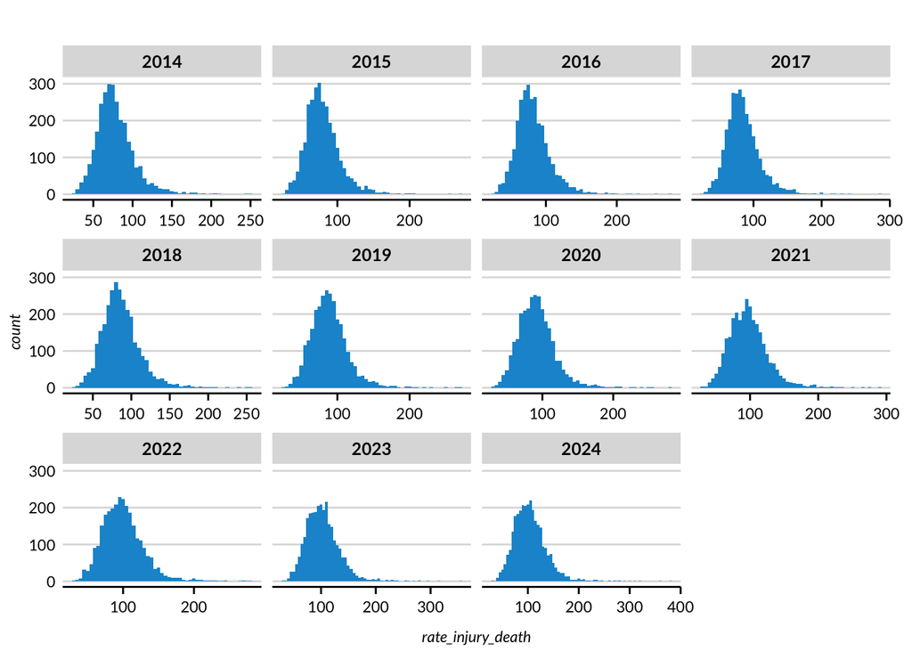

```r
joined_data |>
  filter(!is.na(rate_injury_death) & subgroup=="all") |>
  ggplot(aes(rate_injury_death)) +
  geom_histogram(binwidth = 5) +
  facet_wrap(~ year, scales = "free_x") +
  labs(title = "")
```

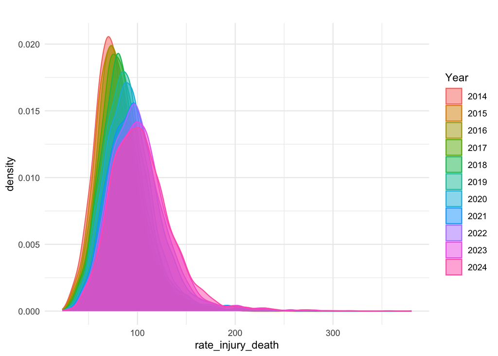

```r
joined_data |>
  filter(!is.na(rate_injury_death) & subgroup == "all") |>
  ggplot(aes(x = rate_injury_death, fill = factor(year), color = factor(year))) +
  geom_density(alpha = 0.5) +
  labs(title = "", fill = "Year", color = "Year") +
  theme_minimal()
```

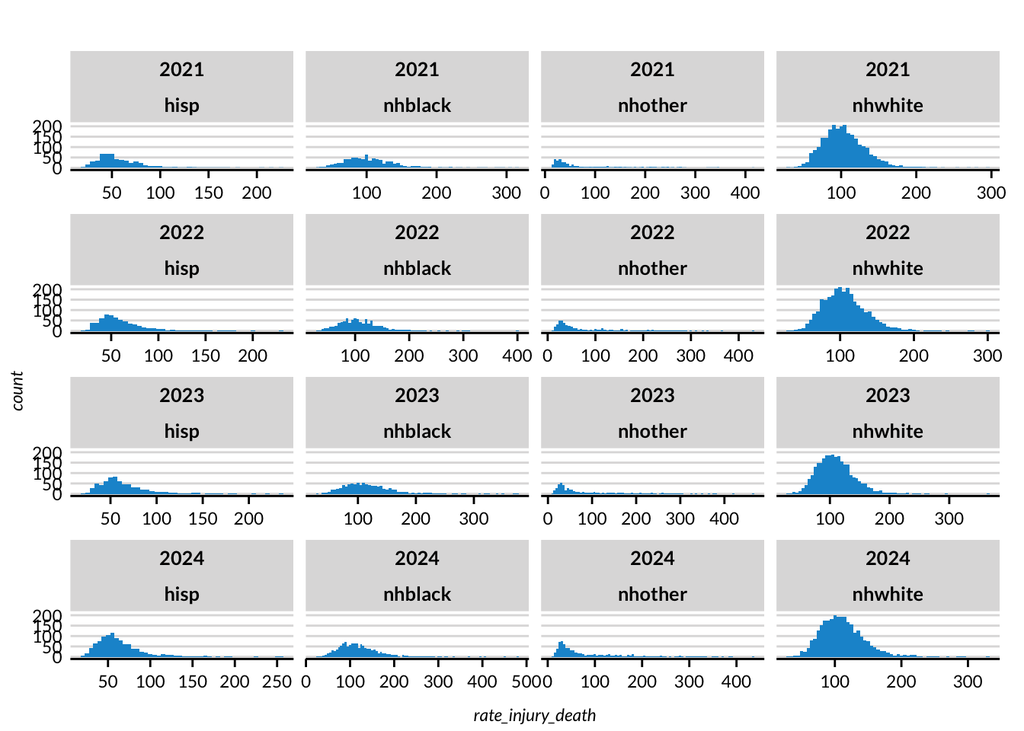

```r
joined_data |>
  filter(!is.na(rate_injury_death) & subgroup!="all") |>
  ggplot(aes(rate_injury_death)) +
  geom_histogram(binwidth = 5) +
  facet_wrap(~ year + subgroup, scales = "free_x") +
  labs(title = "")
```

Check where high injury death rates are concentrated

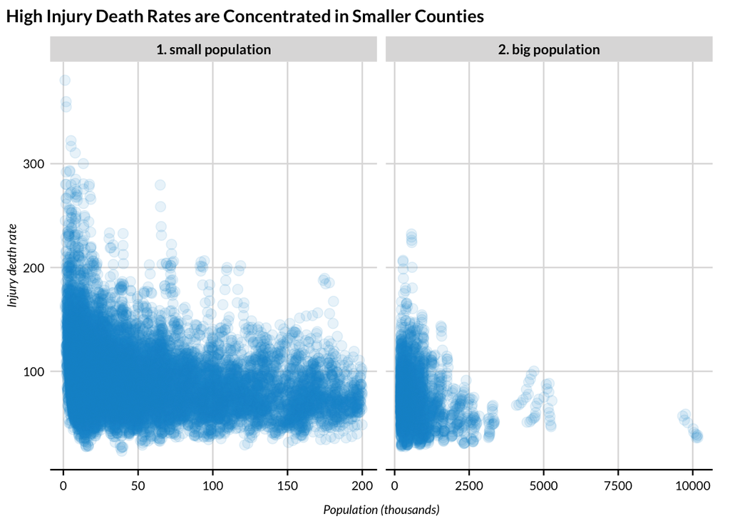

```r
joined_data |>
  filter(!is.na(population),
         !is.na(rate_injury_death),
         subgroup=="all") |>
  mutate(size = if_else(population < 200000, "1. small population", "2. big population")) |>
  # Standardize population by denominating in 1000s so the axis labels are more legible
  mutate(population = population / 1000) |>
  ggplot(aes(population, rate_injury_death)) +
  geom_point(alpha = 0.1) +
  facet_wrap(~ size, scales = "free_x") +
  labs(title = "High Injury Death Rates are Concentrated in Smaller Counties",
       x = "Population (thousands)",
       y = "Injury death rate") +
  scatter_grid()
```

Check relationship between number of injury deaths and injury death rates

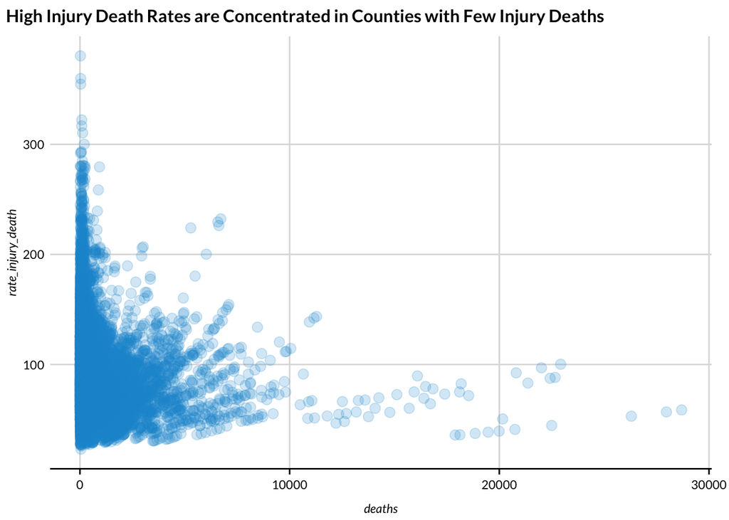

```r
joined_data |>
  filter(!is.na(rate_injury_death),
         !is.na(deaths),
         subgroup=="all") |>
  ggplot(aes(deaths, rate_injury_death)) +
  geom_point(alpha = 0.2) +
  labs(title = "High Injury Death Rates are Concentrated in Counties with Few Injury Deaths") +
  scatter_grid()
```

## 5. Add data quality flags

This section creates a variable for the coefficient of variation (CV) for each county and assigns a quality indicator based on that county’s CV. Smaller CVs are indicative of high quality data.

```r
joined_data <- joined_data |>
  mutate(cv = rate_injury_death_se / rate_injury_death)
```

```r
joined_data |>
  group_by(year) |>
  summarise(
    quantiles = list(quantile(cv,
                              probs = c(0, 0.2, 0.4, 0.6, 0.8, 0.9, 0.99, 1),
                              na.rm = TRUE))
  ) |>
  unnest_wider(quantiles)
```

```
# A tibble: 11 × 9
    year    `0%`  `20%`  `40%`  `60%` `80%` `90%` `99%` `100%`
   <dbl>   <dbl>  <dbl>  <dbl>  <dbl> <dbl> <dbl> <dbl>  <dbl>
 1  2014 0.00836 0.0539 0.0802 0.106  0.141 0.171 0.219  0.225
 2  2015 0.00830 0.0533 0.0796 0.105  0.141 0.172 0.218  0.224
 3  2016 0.00760 0.0522 0.0787 0.104  0.140 0.169 0.218  0.224
 4  2017 0.00779 0.0508 0.0775 0.102  0.138 0.169 0.218  0.225
 5  2018 0.00761 0.0497 0.0768 0.102  0.138 0.167 0.218  0.224
 6  2019 0.00732 0.0492 0.0754 0.101  0.136 0.165 0.214  0.224
 7  2020 0.00673 0.0479 0.0742 0.0991 0.134 0.166 0.215  0.224
 8  2021 0.0075  0.0572 0.0874 0.119  0.160 0.189 0.223  0.225
 9  2022 0.00566 0.0523 0.0799 0.110  0.152 0.183 0.219  0.225
10  2023 0.00527 0.0514 0.0792 0.109  0.151 0.183 0.223  0.225
11  2024 0.00511 0.0557 0.0874 0.126  0.190 0.243 0.316  0.318
```

```r
joined_data <- joined_data |>
  mutate(
    rate_injury_death_quality = case_when(
      cv < 0.2 ~ 1,
      cv < 0.4 ~ 2,
      cv >= 0.4 | GEOID %in% c("02063", "02066") ~ 3
    )
  )
```

Ensure that all observations with missing rate also have missing quality

```r
joined_data |>
  filter(is.na(rate_injury_death) & !is.na(rate_injury_death_quality)) |>
  count()
```

```
# A tibble: 1 × 1
      n
  <int>
1    20
```

```r
joined_data <- joined_data |>
  mutate(
    rate_injury_death_quality = case_when(
      is.na(rate_injury_death) ~ NA,
      TRUE ~ rate_injury_death_quality
    )
  )
```

Only a handful of observations have a data quality value of 3 (Chugach Census Area, AK and Copper River Census Area, AK in each year 2020-2024).

```r
joined_data |>
  group_by(subgroup) |>
  count(rate_injury_death_quality)
```

```
# A tibble: 18 × 3
# Groups:   subgroup [5]
   subgroup rate_injury_death_quality     n
   <chr>                        <dbl> <int>
 1 all                              1 30544
 2 all                              2  1171
 3 all                              3    10
 4 all                             NA  2845
 5 hisp                             1  2200
 6 hisp                             2   704
 7 hisp                            NA  9671
 8 nhblack                          1  3195
 9 nhblack                          2   669
10 nhblack                         NA  8711
11 nhother                          1  1554
12 nhother                          2   499
13 nhother                          3     4
14 nhother                         NA 10518
15 nhwhite                          1 10560
16 nhwhite                          2   622
17 nhwhite                          3     8
18 nhwhite                         NA  1385
```

Most estimates have small coefficients of variation and are therefore of high quality.

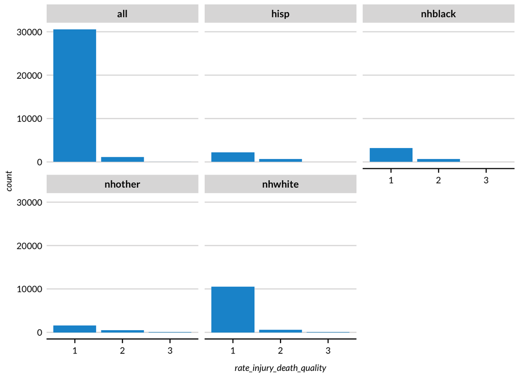

```r
joined_data |>
  group_by(subgroup) |>
  filter(!is.na(rate_injury_death_quality)) |>
  ggplot(aes(x = rate_injury_death_quality)) +
  facet_wrap(~ subgroup) +
  geom_bar()
```

```r
joined_data |>
  group_by(subgroup) |>
  count(rate_injury_death_quality)
```

```
# A tibble: 18 × 3
# Groups:   subgroup [5]
   subgroup rate_injury_death_quality     n
   <chr>                        <dbl> <int>
 1 all                              1 30544
 2 all                              2  1171
 3 all                              3    10
 4 all                             NA  2845
 5 hisp                             1  2200
 6 hisp                             2   704
 7 hisp                            NA  9671
 8 nhblack                          1  3195
 9 nhblack                          2   669
10 nhblack                         NA  8711
11 nhother                          1  1554
12 nhother                          2   499
13 nhother                          3     4
14 nhother                         NA 10518
15 nhwhite                          1 10560
16 nhwhite                          2   622
17 nhwhite                          3     8
18 nhwhite                         NA  1385
```

```r
joined_data |>
  filter(is.na(rate_injury_death_quality)) |>
  count(rate_injury_death)
```

```
# A tibble: 1 × 2
  rate_injury_death     n
              <dbl> <int>
1                NA 33130
```

All estimates have small standard errors.

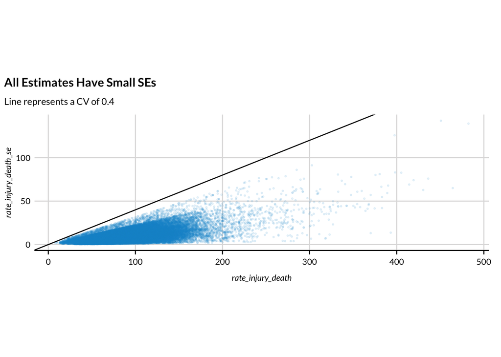

```r
joined_data |>
  filter(!is.na(rate_injury_death_quality)) |>
  ggplot(aes(rate_injury_death, rate_injury_death_se)) +
  geom_point(alpha = 0.1, size = 0.5) +
  geom_abline(aes(slope = 0.4, intercept = 0)) +
  labs(title = "All Estimates Have Small SEs",
       subtitle = "Line represents a CV of 0.4") +
  coord_equal() +
  scatter_grid()
```

## 6. Save and write out data

```r
testthat::test_that("Check that if the rate is missing, CIs and quality are also missing", {

  missing_condition <- is.na(joined_data$rate_injury_death) &
                       (!is.na(joined_data$rate_injury_death_lb) |
                        !is.na(joined_data$rate_injury_death_ub) |
                        !is.na(joined_data$rate_injury_death_quality))

  expect_false(any(missing_condition))

})
```

```
Test passed 😀
```

```r
testthat::test_that("Check that if the rate is not missing, CIs and quality are also not missing", {

  missing_condition <- !is.na(joined_data$rate_injury_death) &
                       (is.na(joined_data$rate_injury_death_lb) |
                        is.na(joined_data$rate_injury_death_ub) |
                        is.na(joined_data$rate_injury_death_quality))

  expect_false(any(missing_condition))

})
```

```
Test passed 😀
```

```r
# Remove unnecessary variables and sort by year, state, and county
final_all <- joined_data |>
  filter(subgroup=="all") |>
  select(
    year,
    state,
    county,
    rate_injury_death,
    rate_injury_death_lb,
    rate_injury_death_ub,
    rate_injury_death_quality,
  ) |>
  arrange(year, state, county)
```

```r
evaluate_final_data(
  exp_form_path = "10a_final-evaluation/evaluation_form_injury_death_overall_county.csv",
  data = final_all,
  geography = "county",
  subgroups = FALSE,
  confidence_intervals = TRUE
  )
```

```
[1] "This data passes all tests!"
```

```r
# Write out final data
write_csv(x = final_all,
          file = here::here(
            "20_safety-from-trauma",
            "data",
            "final",
            "rate_injury_deaths_metric_all_county.csv"
          )
)
```

```r
# Remove unnecessary variables and sort by year, state, county, and subgroup
final_subgroup <- joined_data |>
  # Subgroup observations only apply for years 2021 and later
  filter(year %in% c(2021, 2022, 2023, 2024)) |>
  mutate(
    subgroup_type = case_when(
      subgroup %in% c("nhwhite", "nhblack", "hisp", "nhother") ~ "race-ethnicity",
      subgroup == "all" ~ "all",
      TRUE ~ NA
    ),
    subgroup = case_when(
      subgroup == "all" ~ "All",
      subgroup == "nhwhite" ~ "White, Non-Hispanic",
      subgroup == "nhblack" ~ "Black, Non-Hispanic",
      subgroup == "hisp" ~ "Hispanic",
      subgroup == "nhother" ~ "Other Races and Ethnicities",
    )
  ) |>
  select(
    year,
    state,
    county,
    subgroup_type,
    subgroup,
    rate_injury_death,
    rate_injury_death_lb,
    rate_injury_death_ub,
    rate_injury_death_quality
  ) |>
  arrange(year, state, county, subgroup_type, subgroup)
```

```r
evaluate_final_data(
  exp_form_path = "10a_final-evaluation/evaluation_form_injury_death_subgroup_county.csv",
  data = final_subgroup,
  geography = "county",
  subgroups = TRUE,
  confidence_intervals = TRUE
  )
```

```
[1] "This data passes all tests!"
```

```r
# Write out final data - subgroups
write_csv(x = final_subgroup,
          file = here::here(
            "20_safety-from-trauma",
            "data",
            "final",
            "rate_injury_deaths_metric_subgroup_county.csv"
          )
)
```